# Experimentos com o k-means

## Segmentação: K-Means

Para isso, usarei bibliotecas como NumPy, Matplotlib, Scikit-learn e Scikit-image...

```python
import numpy as np
import matplotlib.pyplot as plt

# Configurações de exibição do matplotlib
%matplotlib inline
plt.rcParams['image.interpolation'] = 'nearest'
plt.rcParams['image.cmap'] = 'gray'
plt.rcParams['figure.dpi'] = 100
```

Todas as imagens de `./dataset/*.jpg` são carregadas, mas por estarem em alta resolução, eu irei rudizir suas dimensões proporcionalmente de modo que as larguras e/ou alturas sejam, no máximo, menor ou igual à `msize`.

É importe ressaltar que, como as imagens estão sendo carregadas ordenadas pelo nome do arquivo (através da função `sorted`), **as primeiras 5 imagens da lista são as fotografadas e o restante, as escaneadas**.

```python
from skimage import transform, io
from glob import glob

def img_resize(image, msize=500):
    t = msize / max(image.shape)
    n = tuple([int(s * t) for s in image.shape[:2]])
    return transform.resize(image, n, mode='reflect')

imgs = []
for file in sorted(glob("./dataset/*.jpg")):
    imgs.append([file.split('/')[-1], img_resize(io.imread(file))])
```

Acima, as imagens (fotogradas e escaneadas) são carregas em uma lista, sendo que cada item dessa lista encontra-se no seguinte formato: `[str("..."), np.array()]`, onde a primeira posição armazena o nome do arquivo enquanto que a segunda, a imagem em um numpy array.

Agora, as imagens passarão por um Processamento Digital de Imagens (PDI), onde 3 operações serão realizadas objetivando a remoção de ruídos e suavização das amostras. Em seguida, cada imagem "pós-pdi" é anexada à lista `imgs`. Essas operações, embora apresentem resultados satisfatórios, são bastante lentas.

```python
from skimage import restoration, filters, exposure

def pdi(image):
    image = restoration.denoise_nl_means(image, h=0.15, multichannel=True)
    image = filters.gaussian(image, sigma=1.6, multichannel=True)
    image = exposure.adjust_gamma(image, gamma=0.5, gain=1)
    return image

for img in imgs:
    img.append(pdi(img[1]))
```

Abaixo, vamos plotar um "antes e depois" das imagens. Na primeira linha encontram-se as imagens carregadas do diretório indicado, sem nenhuma alteração além do redimensionamento, enquanto que a segunda linha expõe as mesmas imagens após o PDI (processo realizado no bloco anterior)

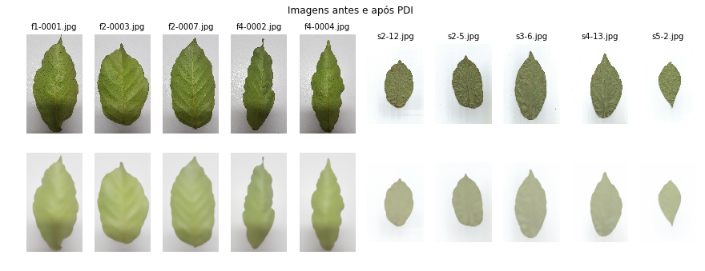

```python
f, ax = plt.subplots(2, 10, figsize=(15, 5))
f.suptitle("Imagens antes e após PDI")

for i in range(2):
    x = 0
    for j in range(10):
        ax[i, j].set_title(imgs[x][0], size=10) if i == 0 else None
        ax[i, j].imshow(imgs[x][1 if i == 0 else 2])
        ax[i, j].axis('off')
        x += 1
```

Abaixo, há a função `kmeans(image2d, shape, k=3)`. Nela, os pixels das imagens são organizados em `k` clusters e, em seguida, a imagem é reconstruída através da função `recreate_image()`, disponível em http://scikit-learn.org/stable/auto_examples/cluster/plot_color_quantization.html.

Essa função será útil quando formos iterar a lista `imgs`, executando o K-Means para cada imagem presente, mais a frente.

```python
def recreate_image(codebook, labels, w, h):
    """Recreate the (compressed) image from the code book & labels"""
    d = codebook.shape[1]
    image = np.zeros((w, h, d))
    label_idx = 0
    for i in range(w):
        for j in range(h):
            image[i][j] = codebook[labels[label_idx]]
            label_idx += 1
    return image

from sklearn.cluster import KMeans
def kmeans(image2d, shape, k=3):
    kmeans = KMeans(n_clusters=k, random_state=0).fit(image2d)
    labels = kmeans.predict(image2d)
    return recreate_image(kmeans.cluster_centers_, labels, *shape)
```

As dimensões de cada imagem serão, agora, convertidas de ($w \leq $ `msize`, $h \leq $ `msize`, $d = 3$) para $(w*h, d)$. Sendo que $w$, $h$ e $d$ correspondem a largura, altura e a quantidade de canais de cor (*depth*), respectivamente.

O resultado desse processo (que é aplicado às imagens já pré-processadas) é armazenado em `img2darray`, enviado a função `kmeans()` junto das dimensões originais da imagem e, em seguida, anexado a lista `imgs`.

```python
for img in imgs:
    w, h, d = realshape = tuple(img[2].shape)
    img2darray = np.reshape(img[2], (w * h, d))
    img.append(kmeans(img2darray, realshape[:2]))
```

Bem, agora que já aplicamos o K-Means, vamos ver os resultados?

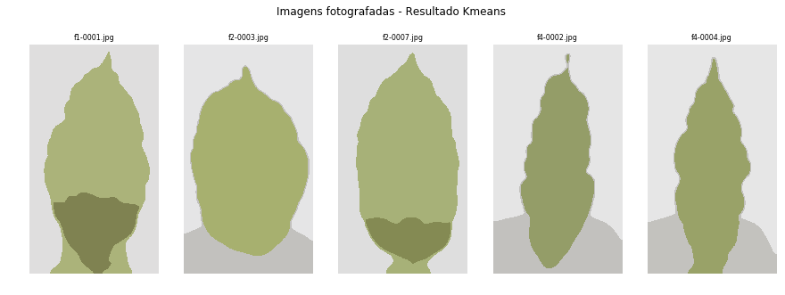

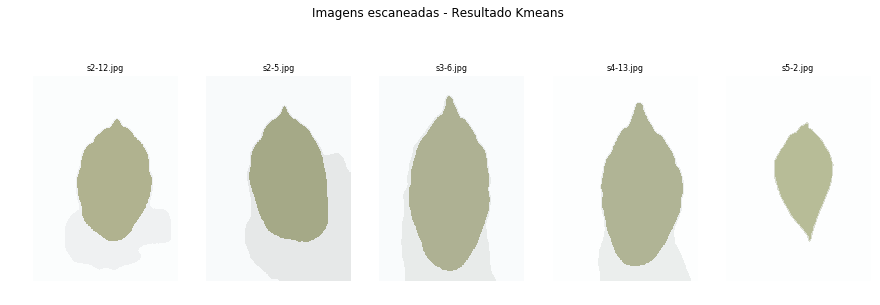

```python
f, ax = plt.subplots(1, 5, figsize=(15, 5))
f.suptitle("Imagens fotografadas - Resultado Kmeans")

for i in range(5):
    ax[i].set_title(imgs[i][0], size=8)
    ax[i].imshow(imgs[i][3])
    ax[i].axis('off')

f, ax = plt.subplots(1, 5, figsize=(15, 5))
f.suptitle("Imagens escaneadas - Resultado Kmeans")

for i in range(5):
    ax[i].set_title(imgs[5+i][0], size=8)
    ax[i].imshow(imgs[5+i][3])
    ax[i].axis('off')
```

Acima, é observável os clusters encontrados pelo K-Means.

### Thresholding e finalização

Agora iremos binarizar os pixels de cada amostra para, em seguida, multiplicarmos o resultado com a imagem original para obtermos apenas a região da folha, sem o fundo.

Iremos utilizar o algoritmo de Otsu para realizar a binarização das amostras:

```python
from skimage.color import rgb2gray
from skimage.filters import threshold_otsu

for img in imgs:
    gray = rgb2gray(img[3])
    binary = gray > threshold_otsu(gray)
    img.append(binary)
```

Vamos conferir o resultado...

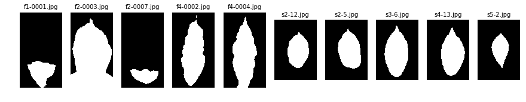

```python
f, ax = plt.subplots(1, 10, figsize=(15, 5))

for i in range(10):
    ax[i].set_title(imgs[i][0], size=10)
    ax[i].imshow(~imgs[i][4])
    ax[i].axis('off')
```

Agora iremos multiplicar cada canal de cor da imagem original (colorida e sem PDI) com a máscara/*kernel* obtido na binarização do output do K-Means

```python
for img in imgs:
    in_img = img[1].copy()
    for i in range(3):
        in_img[:,:,i] *= ~img[4]
    img.append(in_img)
```

Por fim, podemos observar o resultado:

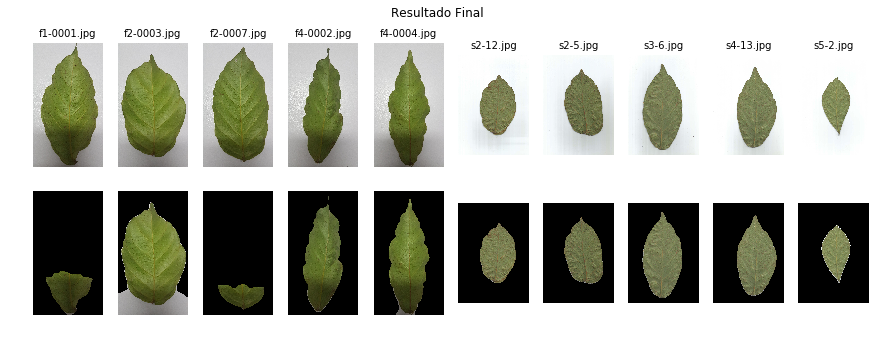

```python
f, ax = plt.subplots(2, 10, figsize=(15, 5))
f.suptitle("Resultado Final")

for i in range(2):
    x = 0
    for j in range(10):
        ax[i, j].set_title(imgs[x][0], size=10) if i == 0 else None
        ax[i, j].imshow(imgs[x][1 if i == 0 else 5])
        ax[i, j].axis('off')
        x += 1
```

### Conclusões

Este experimento utilizou 10 amostras de folíolos dos cultivares de guranazeiros, sendo uma metáde composta de imagens fotografadas e outra de escaneadas, para testar a eficácia de segmentação do algoritmo de classificação não supervionada (clusterizador) K-Means.

Ao longo dos testes, observou-se que a qualidade da segmentação dos folíolos foi consideravelmente dependente das técnicas de PDI utilizadas, principalmente quando se tratando de imagens fotografadas. Isso, de certa forma, é um problema que inviabiliza a utilização deste algoritmo, especialmente para a segmentação dessa categoria de imagens (no contexto deste experimento; *i.e.*, imagens fotografadas), uma vez que não se obteve resultados majoritariamente satisfatórios.

Curiosamente, para as imagens escaneadas, o algoritmo não teve problemas (quando comparado com imagens fotografadas e utilizando os mesmos parâmetros) visivelmente negativos à segmentação dos folíolos. Muito provavelmente, tal resultado esteja atrelado, dentre outros fatores, à uniformidade de brilho dessas imagens e a ausência de sombras passíveis à imagens fotografadas.

Muito em breve, espera-se utilizar outras técnicas de segmentação não supervisonadas como, por exemplo, a [*Watershed*](http://bit.ly/2rtmNeL) ou o algoritmo [*Randon Walker*](https://en.wikipedia.org/wiki/Random_walker_algorithm), para essas mesmas amostras a fim de comparar seus desempenhos com o K-Means.